# Homework 3 - functions and dplyr

Tim Dennis & Reid Otsuji

1/24/2017

## Due 2/4 - By Midnight

### How to submit your homework:

1. Download the r-homework3.R script and open in Rstudio
2. Rename `r-homework3.R` to `yourlastname_sudentID_r-homework3.R`
3. Type the answers in the uncommented lines (those without #).
4. Save the script file.
5. Upload the file to tritonEd for Assignment 3.

## Questions:

1. Write a function called `weighted_mean` that takes a `gapminder` data.frame as an argument and calculates a trimmed or weighted mean of life expectancy by weighing by population. To do this you will assign the output of a function that calculates the the sum of `lifeExp` times pop divided by the sum of pop to a `weighted_mean` object. Hint: Look up the `?sum` function.

```r
weighted_mean <- function(gapminder) {
  #your weighted mean formula here
}
```

2. Use dplyr to filter only rows with the continent of Africa.

```
##   country year      pop continent lifeExp gdpPercap
## 1 Algeria 1952  9279525    Africa  43.077  2449.008
## 2 Algeria 1957 10270856    Africa  45.685  3013.976
## 3 Algeria 1962 11000948    Africa  48.303  2550.817
## 4 Algeria 1967 12760499    Africa  51.407  3246.992
## 5 Algeria 1972 14760787    Africa  54.518  4182.664
## 6 Algeria 1977 17152804    Africa  58.014  4910.417
```

3. Using the filtered `gapminder` data above (only ‘Africa’ rows) with your `weighted_mean` function in question 1, what is the weighted mean of life expectancy of Africa?
4. Create a `dplyr` piped sequence that:
   - Takes gapminder data and uses `group_by` to group by continent
   - Creates a mean variable that conatins the mean of `lifeExp`
   - Creates a `weighted_mean` variable that takes the sum of lifeExp times pop and divides that by the sum of pop – the same formula you used in question 1 above.
   - Print out the resulting dataframe as `weight_mean_dp`
   - The resulting data.frame should look like the below.

Note: You’ll need to use the `summarize` function that `dplyr` gives you.

```
## # A tibble: 5 × 3
##   continent     mean weighted_mean
##      <fctr>    <dbl>         <dbl>
## 1    Africa 48.86533      50.59279
## 2  Americas 64.65874      69.50691
## 3      Asia 60.06490      61.11856
## 4    Europe 71.90369      72.30718
## 5   Oceania 74.32621      75.48954
```

5. Using the built in `iris` dataset, `dplyr`, `tidyr`, and `ggplot2`, write a script that creates a plot comparing the petal and sepal widths and lengths values for each species of flower.

Hint: Start by using tidyr `gather()` function to create a `flowers_df` data frame gathering `Sepal.Length`, `Sepal.Width`, `Petal.Length`, and `Petal.Width` into the key values with `variable` being the ID variable and `value` being the measures. Hint: To express variables you want to `gather` you can use a function like `startsWith()` or use the exclusion operator `-` to tell gather that you want to include everthing but the excluded (e.g `-Species`).

Next use `dplyr` and `ggplot` to create a bar plot comparing the species and values with the geom properties `stat = "identity"` and `position = "dodge"`.

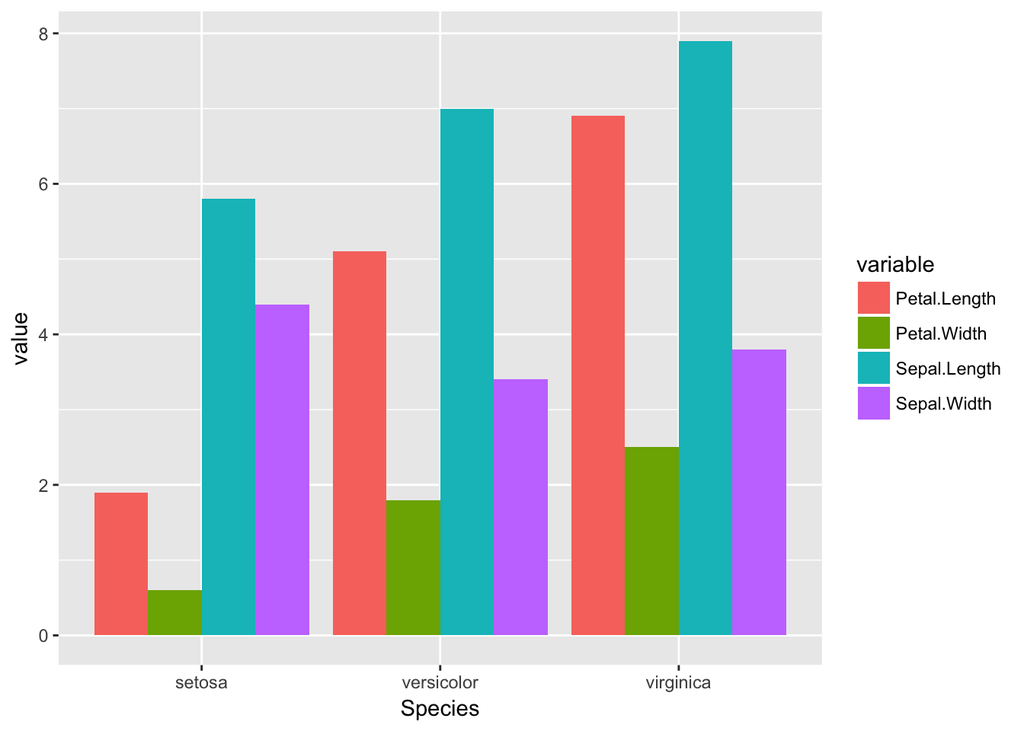